# Explore Restaurant Inspections Data

```r
library(tidyverse)
library(lubridate)
knitr::opts_knit$set(root.dir = "/Users/kathy/Documents/_projects/dc_doh_hackathon")
```

```r
inspection_geocode <- read_csv("data/dc_restaurant_inspections/inspections_geocoded.csv")
inspection_summary <- read_csv("data/dc_restaurant_inspections/potential_inspection_summary_data.csv")
```

[output not shown]

```r
inspection_detail <- read_csv("data/dc_restaurant_inspections/potential_violation_details_data.csv")
```

Let’s look at the distribution of days since last inspection to determine typical inspeciton frequencies based on risk category.

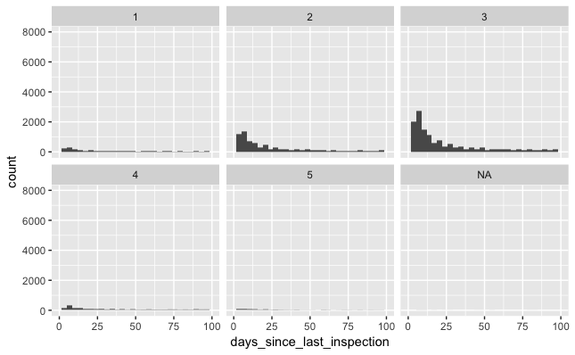

```r
inspection_summary_1 <- inspection_summary %>%
  arrange(establishment_name, inspection_date) %>%
  group_by(establishment_name) %>%
  mutate(days_since_last_inspection = as.numeric(inspection_date - lag(inspection_date)))
inspection_summary_1 %>%
  select(establishment_name, inspection_date, days_since_last_inspection) %>%
  View()
inspection_summary_1 %>%
  filter(!is.na(days_since_last_inspection)) %>%
  ggplot() +
  geom_histogram(aes(days_since_last_inspection)) +
  facet_wrap(~risk_category) +
  xlim(0, 100)
```

Maybe it’s because we have included follow ups and complaint-based inspections. Let’s only include routine inspections.

```r
inspection_summary_1 %>%
  ungroup() %>%
  count(inspection_type) %>%
  arrange(desc(n))
```

| inspection_type | n |
| --- | --- |
| Routine | 29888 |
| Follow-up | 16158 |
| Complaint | 11364 |
| Preoperational | 3282 |
| License Renewal | 2219 |
| Restoration | 903 |
| Other | 795 |
| Initial | 404 |
| Ownership change | 270 |
| NA | 205 |

[output cut: 438 more lines]

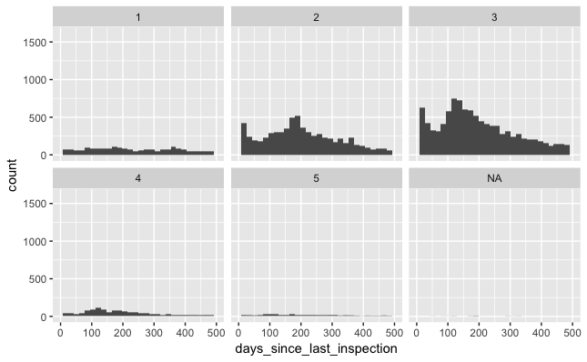

```r
inspection_summary_1 %>%
  filter(!is.na(days_since_last_inspection), inspection_type == "Routine") %>%
  ggplot() +
  geom_histogram(aes(days_since_last_inspection)) +
  facet_wrap(~risk_category) +
  xlim(0, 500)
```

Actually, instead of only plotting routine inspections, we have to re-calculate days since last inspection to include only routine inspections.

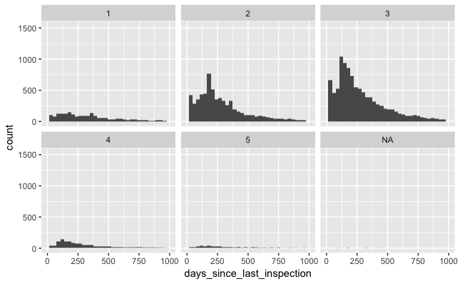

```r
inspection_summary_1 <- inspection_summary %>%
  filter(inspection_type == "Routine") %>%
  arrange(establishment_name, inspection_date) %>%
  group_by(establishment_name) %>%
  mutate(days_since_last_inspection = as.numeric(inspection_date - lag(inspection_date)))
inspection_summary_1 %>%
  select(establishment_name, inspection_date, days_since_last_inspection) %>%
  View()
inspection_summary_1 %>%
  filter(!is.na(days_since_last_inspection)) %>%
  ggplot() +
  geom_histogram(aes(days_since_last_inspection), binwidth = 30) +
  facet_wrap(~risk_category) +
  xlim(0, 1000)
```

This yields a more clear pattern, although it’s still hard to see any distinct cutoffs.

Let’s look at where the deciles fall for each risk category.

```r
p = seq(0, 1, 0.1)
inspection_summary_1 %>%
  ungroup() %>%
  group_by(risk_category) %>%
  summarise(quantiles = list(sprintf("%1.0f%%", p*100)),
            days = list(quantile(days_since_last_inspection, p, na.rm = TRUE))) %>%
  unnest() %>%
  spread(quantiles, days)
```

|  | risk_category | 0% | 10% | 100% | 20% | 30% | 40% | 50% | 60% | 70% | 80% | 90% |
| --- | --- | --- | --- | --- | --- | --- | --- | --- | --- | --- | --- | --- |
| 1 | 1 | 0 | 7.0 | 3360 | 84.0 | 144.0 | 197.8 | 279.0 | 357.0 | 452.0 | 628.4 | 980.3 |
| 2 | 2 | 0 | 6.0 | 3269 | 41.0 | 112.0 | 164.0 | 195.0 | 248.0 | 314.0 | 399.0 | 610.0 |
| 3 | 3 | 0 | 8.0 | 28125 | 57.0 | 121.0 | 153.0 | 194.0 | 248.0 | 321.0 | 425.0 | 609.2 |
| 4 | 4 | 0 | 33.0 | 2234 | 98.0 | 131.0 | 165.0 | 205.0 | 256.0 | 326.0 | 428.4 | 612.7 |
| 5 | 5 | 0 | 63.0 | 1602 | 109.0 | 140.0 | 178.0 | 221.0 | 273.0 | 335.0 | 434.0 | 622.0 |
| 6 | NA | 86 | 105.8 | 465 | 123.6 | 172.3 | 188.6 | 192.5 | 255.8 | 310.3 | 318.4 | 327.1 |

Ok, it looks like it will be hard to set cutoffs based on, say, the 90th percentile of days between inspections, because it looks like other than category 1, the rest of the categories are inspected at about the same frequency. It also looks like there is a wide range of inspection frequencies within each category.

For now it’s use some placeholders… - Category 1: 900 days - Category 2-5: 600 days

Next I want to look at the date range of the file.

```r
range(inspection_summary_1$inspection_date, na.rm = TRUE)
```

```
[1] "1931-12-23" "2019-08-18"
```

These dates don’t make sense. Let’s look at the first and last few dates.

```r
dates <- inspection_summary_1 %>%
  count(inspection_date) %>%
  arrange(inspection_date)
head(dates, 50)
```

| establishment_name | inspection_date | n |
| --- | --- | --- |
| AMAZON CAFE | 1931-12-23 | 1 |
| GRILL KABOB | 1931-12-23 | 1 |
| QUIZNOS | 1931-12-23 | 1 |
| NAGE AT THE COURTYARD BY MARRIOTT EMBASSY ROW | 2000-12-15 | 1 |
| MARVELOUS MARKET | 2006-10-16 | 1 |
| SOHO CAFE & MARKET | 2007-05-04 | 1 |
| RUTH'S CHRIS STEAK HOUSE(n) | 2007-08-14 | 1 |
| MARVELOUS MARKET | 2007-09-12 | 1 |
| SOHO CAFE & MARKET | 2007-09-20 | 1 |
| RUTH CHRIS (n) | 2007-10-09 | 1 |

[output cut: 40 more lines]

```r
tail(dates, 50)
```

| establishment_name | inspection_date | n |
| --- | --- | --- |
| CRUMBS AND WHISKERS | 2017-09-07 | 1 |
| FISH KING DELICATESSEN | 2017-09-07 | 1 |
| FISHERY SEAFOOD MARKET | 2017-09-07 | 1 |
| GALLERY MARKET | 2017-09-07 | 1 |
| GALLUDET BOOKSTORE | 2017-09-07 | 1 |
| GWU DUNKIN DONUTS BASKIN ROBBINS | 2017-09-07 | 1 |
| J.O. WILSON ELEMENTARY SCHOOL | 2017-09-07 | 1 |
| JETTI'S | 2017-09-07 | 1 |
| KINGSMAN ACADEMY PUBLIC CHARTER SCHOOL | 2017-09-07 | 1 |
| KITCHEN NO. 1 CARRYOUT | 2017-09-07 | 1 |

[output cut: 40 more lines]